# Tutorial for package cbsots

Rob van Harrevelt

2020-09-08

# 1 Introduction

Package `cbsots` can be used to retrieve timeseries from the [CBS open data interface](http://www.cbs.nl/nl-NL/menu/cijfers/statline/open-data/default.htm) interface, employing package cbsodataR.

Package cbsodataR can be used to retrieve data of CBS tables using R code. Most tables are complex multi-dimensional tables, and extracting timeseries with appropriate names will usually require some further R programming. The purpose of `cbsots` is to take this programming off your hands.

The packages provides the Shiny App “CBS Timeseries Coding” for specifying which portions of the table you want to retrieve and how the names of the individual timeseries (the so-called “timeseries coding”) should be constructed, and a separate function `get_ts` for actually creating the timeseries based on the timeseries coding created with the Shiny App.

The workflow when using package `cbsots` to retrieve timeseries thus consists of two separate steps:

1. Create or modify the timeseries coding for one or more CBS tables with Shiny App “CBS Timeseries Coding”. The timeseries coding is stored in an rds file.
2. Use function `get_ts` to retrieve the timeseries, using the timeseries coding read from the rds file created in step 1.

Step 1 (using the Shiny App) is only necessary if you add a new table, or want to modify the timeseries coding for an existing table.

In this tutorial, an example of this approach is presented. You can follow this tutotial step by step.

# 2 Table 70076ned: consumption households

For this tutorial we will use CBS table `70076NED`, that contains the consumption of households in the Netherlands for different kinds of goods and services. The table contains different types of consumption timeseries, such as volume changes, value changes, volume indices and value indices.

The language of this table is Dutch. Package `cbsots` currently only supports Dutch tables. There are a few English table provided by the CBS open data portal, but the overwhelming majority of the tables are only provided in Dutch. In this tutorial, the timeseries names that we use will also be based on Dutch terminology, because most users of package `cbsots` are familiar with naming conventions based on the Dutch terminology.

The aim of this tutorial is to retrieve the following six timeseries:

| Name | Dutch Description | English Desription |
| --- | --- | --- |
| `c___vi` | Totale consumptie, volume-indexcijfers | Volume total consumption, volume indices |
| `c_divi` | Consumptie diensten, volume-indexcijfers | Volume consumption services, volume indices |
| `c_govi` | Consumptie goederen, volume-indexcijfers | Volume consumption goods, volume indices |
| `c___wi` | Totale consumptie, waarde-indexcijfers | Total consumption, value indices |
| `c_diwi` | Consumptie diensten, waarde-indexcijfers | Consumption services, value indices |
| `c_gowi` | Consumptie goederen, waarde-indexcijfers | Consumption goods, value indices |

All indices have base year 2000, so the timeseries have the value 100 in 2000.

# 3 Opening a table in the Shiny App

In the remaining part of this Tutotial, I will show how to obtain these timeseries using `cbosts`. You can follow all examples step by step. Because the examples will create an rds file with timeseries coding, I recommend you to run the R code from a clean working directory.

We start with the Shiny application:

```r
library(cbsots)
edit_ts_code("tscode.rds")
```

The first argument (`"tscode.rds"`) specifies the name of the rds file were the timeseries coding is stored. The file should not exist yet at this point.

[figure not shown]

Empty Shiny App

Since the file `"tscode.rds"` does not exist yet, the timeseries code is empty and there is not existing table yet. To start, press the button `New table` underneath the text `“Create new code table”. After a while, a window titled “New table” (see the picture below) appears which allows you to select from the list of available tables. There is some delay between the moment that you press the button and when the Windows appears, because it has to contact the CBS website to obtain the list of available tables.

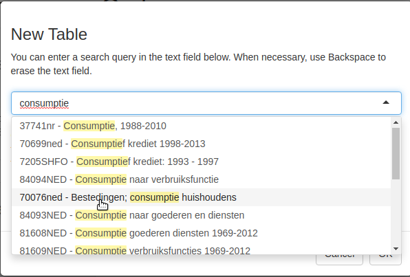

Open new table

In the drop down list, you can enter a search query (words or parts of words occuring in the table description). In this case, type for example `"consumptie"`. A list with all tables containing the word `"consumptie"` in the table description. In the search query, you could also have entered for example, `"70076"`. From that list, select `"70076ned - Bestedingen; consumptie huishoudens"` ans press o.k. Leave the second text field empty and press O.K.

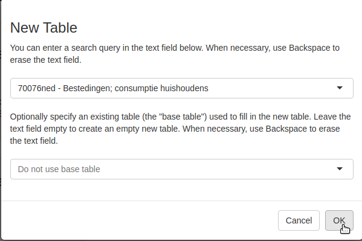

Open new table

# 4 Editing the timeseries coding

# 5 Ordering of dimensions

# 6 Retrieving timeseries with get_ts